# Generation of logistic predictor

Paul Deveau

2017-01-04

# Aim

Test the skills of the candidate to extract relevant features, and see if he can predict using a logistic model.

# Data Generation

```r
e<-runif(n = rows, min = 0, max = 1)
Y<- sapply(X = e,function(z) rbinom(n = 1,size = 1,prob = 1/(1+exp(-10*(0.5 -z)))))
a<-sample(x = 1:10,replace = TRUE,size = rows)
b<-rnorm(n = rows,mean = 0,sd = 1)
c<-rnorm(n = rows,mean = 1,sd = 2)
d<-rnorm(n = rows,mean = 0,sd = 2)
f<-rpois(n = rows, lambda = 5)
g<-rbinom(n = rows, size = 5,prob = 0.3)
h<-rnbinom(n = rows, size = 5, prob = 0.3)

df<-data.frame(a,b,c,d,e,f,g,h,Y)
#colnames(df)<-c(letters[1:(ncol(df)-1)],"Y")
print(head(df))
```

```
##    a          b           c          d         e f g  h Y
## 1 10 -1.3538489 -0.59041503 -1.7761057 0.2875775 7 2 18 1
## 2  4 -0.5793773 -1.27022300  0.7205288 0.7883051 6 0  9 0
## 3  5 -0.8610442  2.16020244  0.8441798 0.4089769 4 2  5 0
## 4  2  0.9726783  2.03608515 -1.4864619 0.8830174 9 0 10 0
## 5  9  0.6191458  1.41537084  0.3604426 0.9404673 5 1  8 0
## 6  3  1.3854457  0.03318627  1.9315134 0.0455565 4 3  4 1
```

Then we check that there is no correlation between the columns except for e and Y:

```r
cor(df)[,"Y"]
```

```
##            a            b            c            d            e
## -0.008321376  0.010655889  0.013868746 -0.007516562 -0.754653831
##            f            g            h            Y
##  0.004351213  0.011864427  0.001394897  1.000000000
```

As expected, there is almost no correlation except for e. We can now save the data.

```r
write.table(x = df, file = "dataset1.tsv",col.names = TRUE, row.names = FALSE,sep ="\t")
```

Then we look at the coefficient of the regression:

```r
logi<-glm(formula = Y ~ e, family = "binomial",data = df)

print(logi)
```

```
##
## Call:  glm(formula = Y ~ e, family = "binomial", data = df)
##
## Coefficients:
## (Intercept)            e
##       4.981      -10.017
##
## Degrees of Freedom: 9999 Total (i.e. Null);  9998 Residual
## Null Deviance:       13860
## Residual Deviance: 6451  AIC: 6455
```

Now we can plot the data:

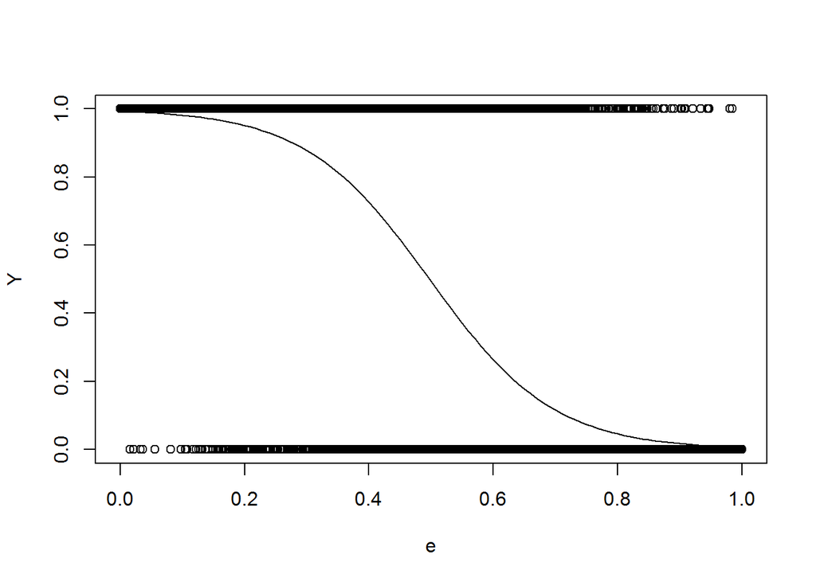

```r
sam<-sample(x = 1:10**4,size = 500)
plot(x = e,y=Y)
curve(predict(logi,data.frame(e=x),type="resp"),add=TRUE)
```

Finally we predict on the following points (only the value of e is used of course): 1. (3,0.8,-2,3, e = 0.6, 4,2,8) 2. (4,0.3,2,-3, e = 0.1, 1,4,3)

```r
preds<-predict.glm(logi, newdata= data.frame(e=c(0.6,0.1)),type = "response")
```

We can now conclude that for 1. we have a probability of 0.2631615 of obtaining a 1, and 0.9816366 for 2.